# Project#0 of AI Course of University of Tehran

Rasta Tadayon 810196436

# Introduction to AI and Python Libraries

The objective for this computer assignment is to get somewhat familier with python libraries such as `pandas`, `numpy` and `matplotlib`. To do so we will be working with a dataset containing data about students. Based on this data we will be predicting whether or not the students will get addmitted to universities in the United States for postgraduate education using linear regression.

The steps to this assignment are throughly explained in the later sections.

## Part 1

```python
import pandas as pd
import numpy as np
import matplotlib.pyplot as plt
```

### Reading csv file into a dataframe

```python
data = pd.read_csv("AdmissionPredict.csv")
data
```

|  | Serial No. | GRE Score | TOEFL Score | University Rating | SOP | LOR | CGPA | Research | Chance of Admit |
| --- | --- | --- | --- | --- | --- | --- | --- | --- | --- |
| 0 | 1 | 337.0 | 118.0 | 4 | 4.5 | 4.5 | 9.65 | 1 | 0.92 |
| 1 | 2 | 324.0 | 107.0 | 4 | 4.0 | 4.5 | 8.87 | 1 | NaN |
| 2 | 3 | 316.0 | NaN | 3 | 3.0 | 3.5 | 8.00 | 1 | 0.72 |
| 3 | 4 | NaN | 110.0 | 3 | 3.5 | 2.5 | 8.67 | 1 | 0.80 |
| 4 | 5 | 314.0 | 103.0 | 2 | 2.0 | 3.0 | 8.21 | 0 | 0.65 |
| 5 | 6 | 330.0 | 115.0 | 5 | 4.5 | 3.0 | 9.34 | 1 | 0.90 |
| 6 | 7 | 321.0 | 109.0 | 3 | 3.0 | 4.0 | NaN | 1 | 0.75 |
| 7 | 8 | 308.0 | 101.0 | 2 | 3.0 | 4.0 | 7.90 | 0 | 0.68 |
| 8 | 9 | 302.0 | 102.0 | 1 | 2.0 | 1.5 | 8.00 | 0 | 0.50 |
| 9 | 10 | 323.0 | 108.0 | 3 | 3.5 | 3.0 | 8.60 | 0 | 0.45 |
| 10 | 11 | 325.0 | 106.0 | 3 | 3.5 | 4.0 | 8.40 | 1 | 0.52 |
| 11 | 12 | NaN | 111.0 | 4 | 4.0 | 4.5 | 9.00 | 1 | 0.84 |
| 12 | 13 | 328.0 | 112.0 | 4 | 4.0 | 4.5 | 9.10 | 1 | 0.78 |
| 13 | 14 | 307.0 | 109.0 | 3 | 4.0 | 3.0 | 8.00 | 1 | 0.62 |
| 14 | 15 | 311.0 | 104.0 | 3 | 3.5 | 2.0 | 8.20 | 1 | 0.61 |
| 15 | 16 | 314.0 | 105.0 | 3 | 3.5 | 2.5 | 8.30 | 0 | 0.54 |
| 16 | 17 | 317.0 | 107.0 | 3 | 4.0 | 3.0 | 8.70 | 0 | 0.66 |
| 17 | 18 | 319.0 | 106.0 | 3 | 4.0 | 3.0 | 8.00 | 1 | 0.65 |
| 18 | 19 | 318.0 | 110.0 | 3 | 4.0 | 3.0 | 8.80 | 0 | 0.63 |
| 19 | 20 | 303.0 | 102.0 | 3 | 3.5 | 3.0 | 8.50 | 0 | 0.62 |
| 20 | 21 | 312.0 | 107.0 | 3 | 3.0 | 2.0 | 7.90 | 1 | 0.64 |
| 21 | 22 | 325.0 | 114.0 | 4 | 3.0 | 2.0 | 8.40 | 0 | 0.70 |
| 22 | 23 | 328.0 | 116.0 | 5 | 5.0 | 5.0 | 9.50 | 1 | 0.94 |
| 23 | 24 | 334.0 | 119.0 | 5 | 5.0 | 4.5 | 9.70 | 1 | 0.95 |
| 24 | 25 | 336.0 | 119.0 | 5 | 4.0 | 3.5 | 9.80 | 1 | 0.97 |
| 25 | 26 | 340.0 | 120.0 | 5 | 4.5 | 4.5 | 9.60 | 1 | 0.94 |
| 26 | 27 | 322.0 | 109.0 | 5 | 4.5 | 3.5 | 8.80 | 0 | 0.76 |
| 27 | 28 | 298.0 | NaN | 2 | 1.5 | 2.5 | NaN | 1 | 0.44 |
| 28 | 29 | 295.0 | 93.0 | 1 | 2.0 | 2.0 | 7.20 | 0 | 0.46 |
| 29 | 30 | 310.0 | 99.0 | 2 | 1.5 | 2.0 | 7.30 | 0 | 0.54 |
| ... | ... | ... | ... | ... | ... | ... | ... | ... | ... |
| 370 | 371 | 310.0 | 103.0 | 2 | 2.5 | 2.5 | 8.24 | 0 | 0.72 |
| 371 | 372 | 324.0 | 110.0 | 3 | 3.5 | 3.0 | 9.22 | 1 | 0.89 |
| 372 | 373 | 336.0 | NaN | 4 | 4.5 | 4.0 | 9.62 | 1 | 0.95 |
| 373 | 374 | 321.0 | 109.0 | 3 | 3.0 | 3.0 | 8.54 | 1 | 0.79 |
| 374 | 375 | 315.0 | 105.0 | 2 | 2.0 | 2.5 | 7.65 | 0 | 0.39 |
| 375 | 376 | 304.0 | 101.0 | 2 | 2.0 | 2.5 | 7.66 | 0 | 0.38 |
| 376 | 377 | 297.0 | 96.0 | 2 | 2.5 | 2.0 | 7.43 | 0 | 0.34 |
| 377 | 378 | 290.0 | 100.0 | 1 | 1.5 | 2.0 | 7.56 | 0 | 0.47 |
| 378 | 379 | 303.0 | 98.0 | 1 | 2.0 | 2.5 | 7.65 | 0 | 0.56 |
| 379 | 380 | 311.0 | 99.0 | 1 | 2.5 | 3.0 | 8.43 | 1 | 0.71 |
| 380 | 381 | 322.0 | 104.0 | 3 | 3.5 | 4.0 | 8.84 | 1 | 0.78 |
| 381 | 382 | 319.0 | 105.0 | 3 | 3.0 | 3.5 | 8.67 | 1 | NaN |
| 382 | 383 | 324.0 | 110.0 | 4 | 4.5 | 4.0 | 9.15 | 1 | 0.82 |
| 383 | 384 | 300.0 | 100.0 | 3 | 3.0 | 3.5 | 8.26 | 0 | 0.62 |
| 384 | 385 | NaN | 113.0 | 4 | 5.0 | 5.0 | 9.74 | 1 | 0.96 |
| 385 | 386 | NaN | 117.0 | 5 | 5.0 | 5.0 | 9.82 | 1 | 0.96 |
| 386 | 387 | 302.0 | 101.0 | 2 | 2.5 | 3.5 | 7.96 | 0 | 0.46 |
| 387 | 388 | 307.0 | 105.0 | 2 | 2.0 | 3.5 | 8.10 | 0 | 0.53 |
| 388 | 389 | 296.0 | 97.0 | 2 | 1.5 | 2.0 | 7.80 | 0 | 0.49 |
| 389 | 390 | 320.0 | 108.0 | 3 | 3.5 | 4.0 | 8.44 | 1 | 0.76 |
| 390 | 391 | 314.0 | 102.0 | 2 | 2.0 | 2.5 | 8.24 | 0 | NaN |
| 391 | 392 | 318.0 | 106.0 | 3 | 2.0 | 3.0 | 8.65 | 0 | 0.71 |
| 392 | 393 | 326.0 | 112.0 | 4 | 4.0 | 3.5 | NaN | 1 | 0.84 |
| 393 | 394 | 317.0 | 104.0 | 2 | 3.0 | 3.0 | 8.76 | 0 | 0.77 |
| 394 | 395 | 329.0 | 111.0 | 4 | 4.5 | 4.0 | 9.23 | 1 | 0.89 |
| 395 | 396 | 324.0 | 110.0 | 3 | 3.5 | 3.5 | 9.04 | 1 | 0.82 |
| 396 | 397 | 325.0 | 107.0 | 3 | 3.0 | 3.5 | 9.11 | 1 | NaN |
| 397 | 398 | 330.0 | 116.0 | 4 | 5.0 | 4.5 | 9.45 | 1 | 0.91 |
| 398 | 399 | 312.0 | 103.0 | 3 | 3.5 | 4.0 | 8.78 | 0 | 0.67 |
| 399 | 400 | 333.0 | 117.0 | 4 | 5.0 | 4.0 | 9.66 | 1 | 0.95 |

400 rows × 9 columns

The dataset consists of the following columns and each column or feature has the specified type:

- The student's **serial number**. This feature has integer values.
- **GRE score** of the student. This feature has integer values between 0 to 340.
- **TOEFL score** of the student. This feature has integer values between 0 to 120.
- **Ranking of the university** in which the student was previously studying in. This feature has integer values between 0 to 5.
- **SOP (statement of purpose) score** of the student. This feature is a floating point value ranging from 0 to 5.
- **LOR (letter of recmmendation) score** of the student. This feature is a floating point value ranging from 0 to 5.
- **CGPA score of the student**. This feature is a floating point value ranging from 0 to 10.
- **Research experience**. This feature has a binary value (either 0 or 1).
- **Chance of the student getting addmitted**. This feature represents the probability that the student will get admitted and has floating point values ranging from 0 to 1 (as they are probability values). The rows in this feature that have Nan values represent the test set.

### Calling functions head(), tail() describe() and info() on the dataframe

#### pandas.DataFrame.head(n=5)

This function returns the first n rows of the data frame. If the n variable is not given as the argument to the function (like the following command) it will return the first 5 rows of the data frame by default. It is used to quickly check if the object has the right data type in it.

If n is a negative value, this function returns all the data frame except the last n rows.

Output of the function called on our data frame is shown bellow.

```python
data.head()
```

|  | Serial No. | GRE Score | TOEFL Score | University Rating | SOP | LOR | CGPA | Research | Chance of Admit |
| --- | --- | --- | --- | --- | --- | --- | --- | --- | --- |
| 0 | 1 | 337.0 | 118.0 | 4 | 4.5 | 4.5 | 9.65 | 1 | 0.92 |
| 1 | 2 | 324.0 | 107.0 | 4 | 4.0 | 4.5 | 8.87 | 1 | NaN |
| 2 | 3 | 316.0 | NaN | 3 | 3.0 | 3.5 | 8.00 | 1 | 0.72 |
| 3 | 4 | NaN | 110.0 | 3 | 3.5 | 2.5 | 8.67 | 1 | 0.80 |
| 4 | 5 | 314.0 | 103.0 | 2 | 2.0 | 3.0 | 8.21 | 0 | 0.65 |

#### pandas.DataFrame.tail(n=5)

This function returns the last n rows of the data frame. If the n variable is not given as the argument to the function (like the following command) it will return the last 5 rows of the data frame by default. It is used to quickly take a look at the last rows of data frame after changes are done on the data such as sorting rows or appending rows.

If n is a negative value this function returns all the data frame except for the first n rows.

Output of the function called on our data frame is shown bellow.

```python
data.tail()
```

|  | Serial No. | GRE Score | TOEFL Score | University Rating | SOP | LOR | CGPA | Research | Chance of Admit |
| --- | --- | --- | --- | --- | --- | --- | --- | --- | --- |
| 395 | 396 | 324.0 | 110.0 | 3 | 3.5 | 3.5 | 9.04 | 1 | 0.82 |
| 396 | 397 | 325.0 | 107.0 | 3 | 3.0 | 3.5 | 9.11 | 1 | NaN |
| 397 | 398 | 330.0 | 116.0 | 4 | 5.0 | 4.5 | 9.45 | 1 | 0.91 |
| 398 | 399 | 312.0 | 103.0 | 3 | 3.5 | 4.0 | 8.78 | 0 | 0.67 |
| 399 | 400 | 333.0 | 117.0 | 4 | 5.0 | 4.0 | 9.66 | 1 | 0.95 |

#### pandas.DataFrame.describe(percentiles=None, include=None, exclude=None)

This function returns some basic statistical details like percentile, mean, standard deviation and such of a data frame or a series of numeric values. For variables with values other than numbers NaN is returned for numeric operations.

**Percentiles:** (list-like of numbers, optional argument) This argument defines the percentiles to be included in the output. All values should be between 0 and 1. The default is [.25, .5, .75], which returns the 25th, 50th, and 75th percentiles.

**Include:** (‘all’, list-like of dtypes or None (default), optional argument) This argument describes the list of data types to be included while describing data frame. Default value is None.

**Exclude:** (list-like of dtypes or None (default), optional argument) This argument describes the list of data types to be excluded while describing data frame. Default value is None.

Output of the function with default value of arguments is shown bellow.

```python
data.describe()
```

|  | Serial No. | GRE Score | TOEFL Score | University Rating | SOP | LOR | CGPA | Research | Chance of Admit |
| --- | --- | --- | --- | --- | --- | --- | --- | --- | --- |
| count | 400.000000 | 378.000000 | 380.000000 | 400.000000 | 400.000000 | 400.000000 | 380.000000 | 400.000000 | 384.000000 |
| mean | 200.500000 | 316.759259 | 107.386842 | 3.087500 | 3.400000 | 3.452500 | 8.604737 | 0.547500 | 0.724375 |
| std | 115.614301 | 11.415599 | 6.048645 | 1.143728 | 1.006869 | 0.898478 | 0.599167 | 0.498362 | 0.142964 |
| min | 1.000000 | 290.000000 | 92.000000 | 1.000000 | 1.000000 | 1.000000 | 6.800000 | 0.000000 | 0.340000 |
| 25% | 100.750000 | 308.250000 | 103.000000 | 2.000000 | 2.500000 | 3.000000 | 8.170000 | 0.000000 | 0.640000 |
| 50% | 200.500000 | 317.000000 | 107.000000 | 3.000000 | 3.500000 | 3.500000 | 8.640000 | 1.000000 | 0.730000 |
| 75% | 300.250000 | 325.000000 | 112.000000 | 4.000000 | 4.000000 | 4.000000 | 9.080000 | 1.000000 | 0.830000 |
| max | 400.000000 | 340.000000 | 120.000000 | 5.000000 | 5.000000 | 5.000000 | 9.920000 | 1.000000 | 0.970000 |

Output for different percentiles is shown bellow.

```python
data.describe(percentiles = [0.20, 0.40, 0.60, 0.80])
```

|  | Serial No. | GRE Score | TOEFL Score | University Rating | SOP | LOR | CGPA | Research | Chance of Admit |
| --- | --- | --- | --- | --- | --- | --- | --- | --- | --- |
| count | 400.000000 | 378.000000 | 380.000000 | 400.000000 | 400.000000 | 400.000000 | 380.000000 | 400.000000 | 384.000000 |
| mean | 200.500000 | 316.759259 | 107.386842 | 3.087500 | 3.400000 | 3.452500 | 8.604737 | 0.547500 | 0.724375 |
| std | 115.614301 | 11.415599 | 6.048645 | 1.143728 | 1.006869 | 0.898478 | 0.599167 | 0.498362 | 0.142964 |
| min | 1.000000 | 290.000000 | 92.000000 | 1.000000 | 1.000000 | 1.000000 | 6.800000 | 0.000000 | 0.340000 |
| 20% | 80.800000 | 306.000000 | 102.000000 | 2.000000 | 2.500000 | 2.500000 | 8.068000 | 0.000000 | 0.610000 |
| 40% | 160.600000 | 314.000000 | 106.000000 | 3.000000 | 3.000000 | 3.000000 | 8.450000 | 0.000000 | 0.700000 |
| 50% | 200.500000 | 317.000000 | 107.000000 | 3.000000 | 3.500000 | 3.500000 | 8.640000 | 1.000000 | 0.730000 |
| 60% | 240.400000 | 321.000000 | 109.000000 | 3.000000 | 3.700000 | 3.500000 | 8.760000 | 1.000000 | 0.768000 |
| 80% | 320.200000 | 326.600000 | 113.000000 | 4.000000 | 4.500000 | 4.100000 | 9.140000 | 1.000000 | 0.860000 |
| max | 400.000000 | 340.000000 | 120.000000 | 5.000000 | 5.000000 | 5.000000 | 9.920000 | 1.000000 | 0.970000 |

Since all data types of the columns are numeric, include and exclude arguments won't make a differece because all the numeric values are added by default and string and such values should be specifically include or excluded.

#### pandas.DataFrame.info(verbose=None, buf=None, max_cols=None, memory_usage=None, null_counts=None)

This function prints a concise summary of the data frame and returns None. This method prints information about a data frame including the index data type and column data types, number of non-null values and memory usage.

**Verbose:** (bool, optional argument) This argument indicates whether to print the full summary or not. Default value follows the display.max_info_columns setting. True or False overrides the display.max_info_columns setting.

**Buf:** (writable buffer, optional arugemnt and defaults to sys.stdout) This argument indicates where the output is sent to. By default, the output is printed to sys.stdout. A writable buffer can be passed as this argument if further process to the output is needed.

**Max_cols:** (int, optional) This argument specifies whether total memory usage of the DataFrame elements (including the index) should be displayed. By default, this follows the pandas.options.display.memory_usage setting.

**Null_counts:** (bool, optional) This argument indicates whether to show the non-null counts of each variable or not. By default, this is shown only if the frame is smaller than pandas.options.display.max_info_rows and pandas.options.display.max_info_columns.

Following is the function called with the default arguments.

```python
data.info()
```

```
<class 'pandas.core.frame.DataFrame'>
RangeIndex: 400 entries, 0 to 399
Data columns (total 9 columns):
Serial No.           400 non-null int64
GRE Score            378 non-null float64
TOEFL Score          380 non-null float64
University Rating    400 non-null int64
SOP                  400 non-null float64
LOR                  400 non-null float64
CGPA                 380 non-null float64
Research             400 non-null int64
Chance of Admit      384 non-null float64
dtypes: float64(6), int64(3)
memory usage: 28.2 KB
```

Bellow same function is called such way that null counts won't be shown.

```python
data.info(null_counts=False)
```

```
<class 'pandas.core.frame.DataFrame'>
RangeIndex: 400 entries, 0 to 399
Data columns (total 9 columns):
Serial No.           int64
GRE Score            float64
TOEFL Score          float64
University Rating    int64
SOP                  float64
LOR                  float64
CGPA                 float64
Research             int64
Chance of Admit      float64
dtypes: float64(6), int64(3)
memory usage: 28.2 KB
```

Bellow info function is called with verbose argument equal to false. This way the summary will be very short.

```python
data.info(verbose=False)
```

```
<class 'pandas.core.frame.DataFrame'>
RangeIndex: 400 entries, 0 to 399
Columns: 9 entries, Serial No. to Chance of Admit
dtypes: float64(6), int64(3)
memory usage: 28.2 KB
```

This type of function call is used when the variable count is very large.

### Counting the number of NaNs in each column

To count the number of null (NaN) values of each variable, two functions were used: isnull() function and sum().

**isnull():** This function returns a boolean valued object of the same size as the object it was given. Each boolean value indicates whether the mapped object is NaN or not, if it is NaN the mapped value will be True, if not it will be False.

Following is the output of this function which if comaperd with the original data frame we can see it perfectly distinguishes NaNs and correct values.

```python
data.isnull().head(10)
```

|  | Serial No. | GRE Score | TOEFL Score | University Rating | SOP | LOR | CGPA | Research | Chance of Admit |
| --- | --- | --- | --- | --- | --- | --- | --- | --- | --- |
| 0 | False | False | False | False | False | False | False | False | False |
| 1 | False | False | False | False | False | False | False | False | True |
| 2 | False | False | True | False | False | False | False | False | False |
| 3 | False | True | False | False | False | False | False | False | False |
| 4 | False | False | False | False | False | False | False | False | False |
| 5 | False | False | False | False | False | False | False | False | False |
| 6 | False | False | False | False | False | False | True | False | False |
| 7 | False | False | False | False | False | False | False | False | False |
| 8 | False | False | False | False | False | False | False | False | False |
| 9 | False | False | False | False | False | False | False | False | False |

**sum():** This function calculates and returns the sum of the values of the requested axis. The default value for axis is 0 which refers to columns. This way if the following code is excecuted, the sum function counts the number of True values of each column.

Following is the output of these functions called together.

```python
data.isnull().sum()
```

```
Serial No.            0
GRE Score            22
TOEFL Score          20
University Rating     0
SOP                   0
LOR                   0
CGPA                 20
Research              0
Chance of Admit      16
dtype: int64
```

### Replacing NaN values with the mean of each column (Except for column " Chance of Admit")

To do this task firstly we take the last column and seperate it from the dataframe, do the replacement on every other column of the dataframe. Lastly add the last column to the dataframe once again.

The reason for this seperation is that the function used for this part applies to all the data frame but we want the last column untouched.

Before doing so we check what the type of each column is to make sure after doing the changes on the dataframe type of each variable will stay the same

```python
data.dtypes
```

```
Serial No.             int64
GRE Score            float64
TOEFL Score          float64
University Rating      int64
SOP                  float64
LOR                  float64
CGPA                 float64
Research               int64
Chance of Admit      float64
dtype: object
```

To do the task at hand, the last column is saved in variable lastCol . Then drop() function is used, which deletes rows or columns from the data frame by specifiying column name or index and such. The name of the last argument is given as the column name argument.

As shown bellow the data frame no longer has the Chance of Admit column.

```python
lastCol = data['Chance of Admit']
data = data.drop(columns = 'Chance of Admit')
data
```

|  | Serial No. | GRE Score | TOEFL Score | University Rating | SOP | LOR | CGPA | Research |
| --- | --- | --- | --- | --- | --- | --- | --- | --- |
| 0 | 1 | 337.0 | 118.0 | 4 | 4.5 | 4.5 | 9.65 | 1 |
| 1 | 2 | 324.0 | 107.0 | 4 | 4.0 | 4.5 | 8.87 | 1 |
| 2 | 3 | 316.0 | NaN | 3 | 3.0 | 3.5 | 8.00 | 1 |
| 3 | 4 | NaN | 110.0 | 3 | 3.5 | 2.5 | 8.67 | 1 |
| 4 | 5 | 314.0 | 103.0 | 2 | 2.0 | 3.0 | 8.21 | 0 |
| 5 | 6 | 330.0 | 115.0 | 5 | 4.5 | 3.0 | 9.34 | 1 |
| 6 | 7 | 321.0 | 109.0 | 3 | 3.0 | 4.0 | NaN | 1 |
| 7 | 8 | 308.0 | 101.0 | 2 | 3.0 | 4.0 | 7.90 | 0 |
| 8 | 9 | 302.0 | 102.0 | 1 | 2.0 | 1.5 | 8.00 | 0 |
| 9 | 10 | 323.0 | 108.0 | 3 | 3.5 | 3.0 | 8.60 | 0 |
| 10 | 11 | 325.0 | 106.0 | 3 | 3.5 | 4.0 | 8.40 | 1 |
| 11 | 12 | NaN | 111.0 | 4 | 4.0 | 4.5 | 9.00 | 1 |
| 12 | 13 | 328.0 | 112.0 | 4 | 4.0 | 4.5 | 9.10 | 1 |
| 13 | 14 | 307.0 | 109.0 | 3 | 4.0 | 3.0 | 8.00 | 1 |
| 14 | 15 | 311.0 | 104.0 | 3 | 3.5 | 2.0 | 8.20 | 1 |
| 15 | 16 | 314.0 | 105.0 | 3 | 3.5 | 2.5 | 8.30 | 0 |
| 16 | 17 | 317.0 | 107.0 | 3 | 4.0 | 3.0 | 8.70 | 0 |
| 17 | 18 | 319.0 | 106.0 | 3 | 4.0 | 3.0 | 8.00 | 1 |
| 18 | 19 | 318.0 | 110.0 | 3 | 4.0 | 3.0 | 8.80 | 0 |
| 19 | 20 | 303.0 | 102.0 | 3 | 3.5 | 3.0 | 8.50 | 0 |
| 20 | 21 | 312.0 | 107.0 | 3 | 3.0 | 2.0 | 7.90 | 1 |
| 21 | 22 | 325.0 | 114.0 | 4 | 3.0 | 2.0 | 8.40 | 0 |
| 22 | 23 | 328.0 | 116.0 | 5 | 5.0 | 5.0 | 9.50 | 1 |
| 23 | 24 | 334.0 | 119.0 | 5 | 5.0 | 4.5 | 9.70 | 1 |
| 24 | 25 | 336.0 | 119.0 | 5 | 4.0 | 3.5 | 9.80 | 1 |
| 25 | 26 | 340.0 | 120.0 | 5 | 4.5 | 4.5 | 9.60 | 1 |
| 26 | 27 | 322.0 | 109.0 | 5 | 4.5 | 3.5 | 8.80 | 0 |
| 27 | 28 | 298.0 | NaN | 2 | 1.5 | 2.5 | NaN | 1 |
| 28 | 29 | 295.0 | 93.0 | 1 | 2.0 | 2.0 | 7.20 | 0 |
| 29 | 30 | 310.0 | 99.0 | 2 | 1.5 | 2.0 | 7.30 | 0 |
| ... | ... | ... | ... | ... | ... | ... | ... | ... |
| 370 | 371 | 310.0 | 103.0 | 2 | 2.5 | 2.5 | 8.24 | 0 |
| 371 | 372 | 324.0 | 110.0 | 3 | 3.5 | 3.0 | 9.22 | 1 |
| 372 | 373 | 336.0 | NaN | 4 | 4.5 | 4.0 | 9.62 | 1 |
| 373 | 374 | 321.0 | 109.0 | 3 | 3.0 | 3.0 | 8.54 | 1 |
| 374 | 375 | 315.0 | 105.0 | 2 | 2.0 | 2.5 | 7.65 | 0 |
| 375 | 376 | 304.0 | 101.0 | 2 | 2.0 | 2.5 | 7.66 | 0 |
| 376 | 377 | 297.0 | 96.0 | 2 | 2.5 | 2.0 | 7.43 | 0 |
| 377 | 378 | 290.0 | 100.0 | 1 | 1.5 | 2.0 | 7.56 | 0 |
| 378 | 379 | 303.0 | 98.0 | 1 | 2.0 | 2.5 | 7.65 | 0 |
| 379 | 380 | 311.0 | 99.0 | 1 | 2.5 | 3.0 | 8.43 | 1 |
| 380 | 381 | 322.0 | 104.0 | 3 | 3.5 | 4.0 | 8.84 | 1 |
| 381 | 382 | 319.0 | 105.0 | 3 | 3.0 | 3.5 | 8.67 | 1 |
| 382 | 383 | 324.0 | 110.0 | 4 | 4.5 | 4.0 | 9.15 | 1 |
| 383 | 384 | 300.0 | 100.0 | 3 | 3.0 | 3.5 | 8.26 | 0 |
| 384 | 385 | NaN | 113.0 | 4 | 5.0 | 5.0 | 9.74 | 1 |
| 385 | 386 | NaN | 117.0 | 5 | 5.0 | 5.0 | 9.82 | 1 |
| 386 | 387 | 302.0 | 101.0 | 2 | 2.5 | 3.5 | 7.96 | 0 |
| 387 | 388 | 307.0 | 105.0 | 2 | 2.0 | 3.5 | 8.10 | 0 |
| 388 | 389 | 296.0 | 97.0 | 2 | 1.5 | 2.0 | 7.80 | 0 |
| 389 | 390 | 320.0 | 108.0 | 3 | 3.5 | 4.0 | 8.44 | 1 |
| 390 | 391 | 314.0 | 102.0 | 2 | 2.0 | 2.5 | 8.24 | 0 |
| 391 | 392 | 318.0 | 106.0 | 3 | 2.0 | 3.0 | 8.65 | 0 |
| 392 | 393 | 326.0 | 112.0 | 4 | 4.0 | 3.5 | NaN | 1 |
| 393 | 394 | 317.0 | 104.0 | 2 | 3.0 | 3.0 | 8.76 | 0 |
| 394 | 395 | 329.0 | 111.0 | 4 | 4.5 | 4.0 | 9.23 | 1 |
| 395 | 396 | 324.0 | 110.0 | 3 | 3.5 | 3.5 | 9.04 | 1 |
| 396 | 397 | 325.0 | 107.0 | 3 | 3.0 | 3.5 | 9.11 | 1 |
| 397 | 398 | 330.0 | 116.0 | 4 | 5.0 | 4.5 | 9.45 | 1 |
| 398 | 399 | 312.0 | 103.0 | 3 | 3.5 | 4.0 | 8.78 | 0 |
| 399 | 400 | 333.0 | 117.0 | 4 | 5.0 | 4.0 | 9.66 | 1 |

400 rows × 8 columns

After seperating the last column, fillna() function is used which replaces the NaN values with the specific method it is given. Here since we want to fill them in with mean of each column the mean method is given as input.

Bellow we can see every NaN value is replaced in the data frame.

```python
data = data.fillna(data.mean())
data.head(15)
```

|  | Serial No. | GRE Score | TOEFL Score | University Rating | SOP | LOR | CGPA | Research |
| --- | --- | --- | --- | --- | --- | --- | --- | --- |
| 0 | 1 | 337.000000 | 118.000000 | 4 | 4.5 | 4.5 | 9.650000 | 1 |
| 1 | 2 | 324.000000 | 107.000000 | 4 | 4.0 | 4.5 | 8.870000 | 1 |
| 2 | 3 | 316.000000 | 107.386842 | 3 | 3.0 | 3.5 | 8.000000 | 1 |
| 3 | 4 | 316.759259 | 110.000000 | 3 | 3.5 | 2.5 | 8.670000 | 1 |
| 4 | 5 | 314.000000 | 103.000000 | 2 | 2.0 | 3.0 | 8.210000 | 0 |
| 5 | 6 | 330.000000 | 115.000000 | 5 | 4.5 | 3.0 | 9.340000 | 1 |
| 6 | 7 | 321.000000 | 109.000000 | 3 | 3.0 | 4.0 | 8.604737 | 1 |
| 7 | 8 | 308.000000 | 101.000000 | 2 | 3.0 | 4.0 | 7.900000 | 0 |
| 8 | 9 | 302.000000 | 102.000000 | 1 | 2.0 | 1.5 | 8.000000 | 0 |
| 9 | 10 | 323.000000 | 108.000000 | 3 | 3.5 | 3.0 | 8.600000 | 0 |
| 10 | 11 | 325.000000 | 106.000000 | 3 | 3.5 | 4.0 | 8.400000 | 1 |
| 11 | 12 | 316.759259 | 111.000000 | 4 | 4.0 | 4.5 | 9.000000 | 1 |
| 12 | 13 | 328.000000 | 112.000000 | 4 | 4.0 | 4.5 | 9.100000 | 1 |
| 13 | 14 | 307.000000 | 109.000000 | 3 | 4.0 | 3.0 | 8.000000 | 1 |
| 14 | 15 | 311.000000 | 104.000000 | 3 | 3.5 | 2.0 | 8.200000 | 1 |

After replacin the NaN values correctly we can add the last column to the data frame with the command written bellow and after that we are done.

It can be observed that no column contains NaN values anymore except for the Chance of Admit column and the values are replaced with mean value of the same column (not considering the NaN values).

```python
data['Chance of Admit'] = lastCol
data.head(15)
```

|  | Serial No. | GRE Score | TOEFL Score | University Rating | SOP | LOR | CGPA | Research | Chance of Admit |
| --- | --- | --- | --- | --- | --- | --- | --- | --- | --- |
| 0 | 1 | 337.000000 | 118.000000 | 4 | 4.5 | 4.5 | 9.650000 | 1 | 0.92 |
| 1 | 2 | 324.000000 | 107.000000 | 4 | 4.0 | 4.5 | 8.870000 | 1 | NaN |
| 2 | 3 | 316.000000 | 107.386842 | 3 | 3.0 | 3.5 | 8.000000 | 1 | 0.72 |
| 3 | 4 | 316.759259 | 110.000000 | 3 | 3.5 | 2.5 | 8.670000 | 1 | 0.80 |
| 4 | 5 | 314.000000 | 103.000000 | 2 | 2.0 | 3.0 | 8.210000 | 0 | 0.65 |
| 5 | 6 | 330.000000 | 115.000000 | 5 | 4.5 | 3.0 | 9.340000 | 1 | 0.90 |
| 6 | 7 | 321.000000 | 109.000000 | 3 | 3.0 | 4.0 | 8.604737 | 1 | 0.75 |
| 7 | 8 | 308.000000 | 101.000000 | 2 | 3.0 | 4.0 | 7.900000 | 0 | 0.68 |
| 8 | 9 | 302.000000 | 102.000000 | 1 | 2.0 | 1.5 | 8.000000 | 0 | 0.50 |
| 9 | 10 | 323.000000 | 108.000000 | 3 | 3.5 | 3.0 | 8.600000 | 0 | 0.45 |
| 10 | 11 | 325.000000 | 106.000000 | 3 | 3.5 | 4.0 | 8.400000 | 1 | 0.52 |
| 11 | 12 | 316.759259 | 111.000000 | 4 | 4.0 | 4.5 | 9.000000 | 1 | 0.84 |
| 12 | 13 | 328.000000 | 112.000000 | 4 | 4.0 | 4.5 | 9.100000 | 1 | 0.78 |
| 13 | 14 | 307.000000 | 109.000000 | 3 | 4.0 | 3.0 | 8.000000 | 1 | 0.62 |
| 14 | 15 | 311.000000 | 104.000000 | 3 | 3.5 | 2.0 | 8.200000 | 1 | 0.61 |

As is shown in the previous table the task is done successfully and NaN values are replaced in every column except for the last one. To make sure all the NaN values are removed we can call the functions of the previous part again which will show that no column has null values except the last one.

```python
data.isnull().sum()
```

```
Serial No.            0
GRE Score             0
TOEFL Score           0
University Rating     0
SOP                   0
LOR                   0
CGPA                  0
Research              0
Chance of Admit      16
dtype: int64
```

```python
data.dtypes
```

```
Serial No.             int64
GRE Score            float64
TOEFL Score          float64
University Rating      int64
SOP                  float64
LOR                  float64
CGPA                 float64
Research               int64
Chance of Admit      float64
dtype: object
```

As we can see the data types have stayed the same. You can also see that in the actual table, there are no float values in columns with int type and vise versa

# Part 2

### Plotting scatterplot of every variable against Chance of Admit variable

To draw the plots we can use the plot() function which takes many arguments but the ones needed here are kind of the plot which here is scatter plot and the axes, which are each variable against the Chance of Admit variable. The syntax is as follows.

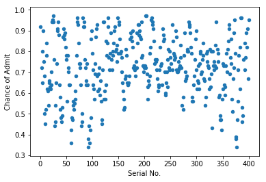

```python
data.plot(kind='scatter', x=0, y='Chance of Admit')
```

Here we have scatter plot of Serial Number against Chance of Admit. It can be observed from the plot that these two variables do not have a meaningful relationship, which is consistant with our every day observations.

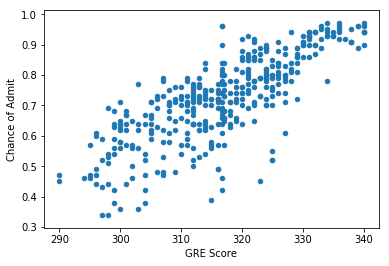

```python
data.plot(kind='scatter', x=1, y='Chance of Admit')
```

Here we have scatter plot of GRE Score against Chance of Admit. It can be observed from the plot that these two variables have a linear relation, where when one variable increases the other one does too.

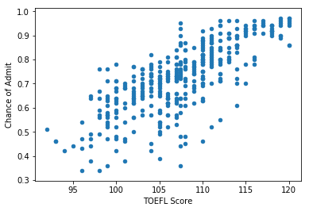

```python
data.plot(kind='scatter', x=2, y='Chance of Admit')
```

Like the previous plot the two variables of this plot also have a linear relationship where when one of them increases the other increases as well and a hypothetical line can be drawn throught the plot to show the relationship.

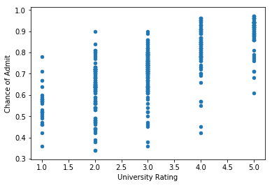

```python
data.plot(kind='scatter', x=3, y='Chance of Admit')
```

This plot shows the scatter plot of University Ranking against Chance of Admit. Since the university ranking variable can only have ingeter values of 1 through 5, this scatter plot is different than the previous 3 plot. However in the sense that, as the university ranking increases the chance of admit increases as well, this plot is like the previous 2 plots.

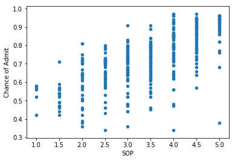

```python
data.plot(kind='scatter', x=4, y='Chance of Admit')
```

In this plot like the previous one it can be observed that the SOP only accepts values of 1, 1.5, 2, 2,5, .., 5. It is obvious that as the SOP value increases the Chnace of Admit also increases which is consistant with our daily observations, beacause the better your SOP score is the higher chance you have in getting admissions.

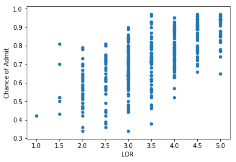

```python
data.plot(kind='scatter', x=5, y='Chance of Admit')
```

This plot is also very similar to the previous one, the same description could be given for both of them.

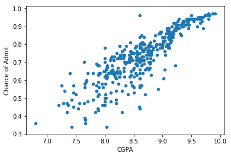

```python
data.plot(kind='scatter', x=6, y='Chance of Admit')
```

In this scatter plot of CGPA against Chance of Admit, it is observed that the two variables have a very strong linear relationship and as one value increases the other one does as well. In the future parts it will be seen that the variable CGPA has the largest correlation with the Chance of Admit variable.

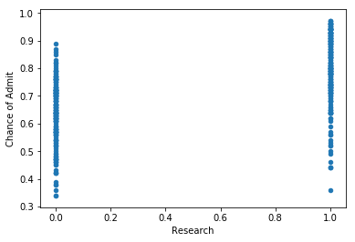

```python
data.plot(kind='scatter', x=7, y='Chance of Admit')
```

Here we have the scatter plot of Research variable against the Chance of Admit variable. It is observed that the Research variable is a binary variable and can only have values 0 or 1. Also it can be seen that the chance of admission increases when the research value equals to 1 however the difference might not be as visible as for example the CGPA variable.

### Chosing the variable with the largest correlation with Chance of Admit variable

To find which of the variablesin the dataframe have the largest linear correlation with Chance of Admit variable we can have a good guess by plotting them however to make sure, we calculate the correlation value. Correlation is a statistical measure of linear correlation between two variable. There are a few different mothods for calculating the correlation, one of them is the Pearson correlation coefficient. The Pearson correlation coefficient is calculated with this formula:

\begin{align*} \rho_{X,Y} = \frac{cov(X,Y)}{\sigma_X \sigma_Y} \end{align*}

In which the $cov(X,Y)$ is the covariance of the two variables. The $\sigma_X$ and $\sigma_y$ are standard deviations of X and Y variables and $\rho_{X,Y}$ represents the correlation value.

The coefficient value falls somewhere between -1 and +1 where a +1 indicates a perfect positive relationship and -1 indicates a perfect negative relationship.

Pandas library has a corr() function which when called without arguments on a data frame calculates the pairwise correlation of the columns (excluding NaN values) and returns a data frame.

The returned data frame from corr function will have 1 along the main diagonals and it is also symmetric.

```python
data.corr()
```

|  | Serial No. | GRE Score | TOEFL Score | University Rating | SOP | LOR | CGPA | Research | Chance of Admit |
| --- | --- | --- | --- | --- | --- | --- | --- | --- | --- |
| Serial No. | 1.000000 | -0.102867 | -0.157648 | -0.169948 | -0.166932 | -0.088221 | -0.062254 | -0.063138 | 0.047057 |
| GRE Score | -0.102867 | 1.000000 | 0.803483 | 0.659972 | 0.599892 | 0.544010 | 0.794507 | 0.572454 | 0.785166 |
| TOEFL Score | -0.157648 | 0.803483 | 1.000000 | 0.681877 | 0.633790 | 0.555354 | 0.799066 | 0.498658 | 0.758534 |
| University Rating | -0.169948 | 0.659972 | 0.681877 | 1.000000 | 0.734523 | 0.660123 | 0.733424 | 0.447783 | 0.707191 |
| SOP | -0.166932 | 0.599892 | 0.633790 | 0.734523 | 1.000000 | 0.729593 | 0.695528 | 0.444029 | 0.680752 |
| LOR | -0.088221 | 0.544010 | 0.555354 | 0.660123 | 0.729593 | 1.000000 | 0.660742 | 0.396859 | 0.663452 |
| CGPA | -0.062254 | 0.794507 | 0.799066 | 0.733424 | 0.695528 | 0.660742 | 1.000000 | 0.514092 | 0.855675 |
| Research | -0.063138 | 0.572454 | 0.498658 | 0.447783 | 0.444029 | 0.396859 | 0.514092 | 1.000000 | 0.548443 |
| Chance of Admit | 0.047057 | 0.785166 | 0.758534 | 0.707191 | 0.680752 | 0.663452 | 0.855675 | 0.548443 | 1.000000 |

Every variable has a correlation of 1 with itself(obviously). Variable CGPA has the largest correlation with variable Chance of Admit with the value of 0.855675 which was also observable in the plots.

It is a given that correlation value is a good representation of how two variables are linearly related, therefor we can observe that CGPA is the most linearly related varible to variable Chance of Admit.

# Part 3

### Calculating the number of students with CGPA scores above 9 and TOEFL scores above 110

To filter students with CGPA scores higher or equal to 9 and TOEFL scores higher or equal to 110 we can use the following syntax.

The first part of the code consists of this part:

```python
data['TOEFL Score'] >= 110
```

```
0       True
1      False
2      False
3       True
4      False
5       True
6      False
7      False
8      False
9      False
10     False
11      True
12      True
13     False
14     False
```

[output cut: 47 more lines]

```python
newdata = data[(data['TOEFL Score'] >= 110) & (data['CGPA'] >= 9)]
newdata.head(15)
```

|  | Serial No. | GRE Score | TOEFL Score | University Rating | SOP | LOR | CGPA | Research | Chance of Admit |
| --- | --- | --- | --- | --- | --- | --- | --- | --- | --- |
| 0 | 1 | 337.000000 | 118.0 | 4 | 4.5 | 4.5 | 9.65 | 1 | 0.92 |
| 5 | 6 | 330.000000 | 115.0 | 5 | 4.5 | 3.0 | 9.34 | 1 | 0.90 |
| 11 | 12 | 316.759259 | 111.0 | 4 | 4.0 | 4.5 | 9.00 | 1 | 0.84 |
| 12 | 13 | 328.000000 | 112.0 | 4 | 4.0 | 4.5 | 9.10 | 1 | 0.78 |
| 22 | 23 | 328.000000 | 116.0 | 5 | 5.0 | 5.0 | 9.50 | 1 | 0.94 |
| 23 | 24 | 334.000000 | 119.0 | 5 | 5.0 | 4.5 | 9.70 | 1 | 0.95 |
| 24 | 25 | 336.000000 | 119.0 | 5 | 4.0 | 3.5 | 9.80 | 1 | 0.97 |
| 25 | 26 | 340.000000 | 120.0 | 5 | 4.5 | 4.5 | 9.60 | 1 | 0.94 |
| 32 | 33 | 338.000000 | 118.0 | 4 | 3.0 | 4.5 | 9.40 | 1 | 0.91 |
| 33 | 34 | 340.000000 | 114.0 | 5 | 4.0 | 4.0 | 9.60 | 1 | 0.90 |
| 34 | 35 | 331.000000 | 112.0 | 5 | 4.0 | 5.0 | 9.80 | 1 | 0.94 |
| 35 | 36 | 320.000000 | 110.0 | 5 | 5.0 | 5.0 | 9.20 | 1 | 0.88 |
| 44 | 45 | 326.000000 | 113.0 | 5 | 4.5 | 4.0 | 9.40 | 1 | 0.91 |
| 45 | 46 | 322.000000 | 110.0 | 5 | 5.0 | 4.0 | 9.10 | 1 | 0.88 |
| 46 | 47 | 329.000000 | 114.0 | 5 | 4.0 | 5.0 | 9.30 | 1 | 0.86 |

A new data frame is created that only includes rows in which the series created in the previous line of code has True value.

The number of students can be obtained by the length of the newly created data frame:

```python
newdata.shape[0]
```

```
97
```

97 students have CGPA scores above 9 and TOEFL scores above 110.

### Calculating mean value of GRE scores of graduate students of each university ranking

For doing this part the pandas groupby function was used which returns a groupby object that contains information about the groups. When the function is called with a column name as argument it spilits the data frame by the values that the specific column takes.

```python
gby = data.groupby('University Rating')
gby.first()
```

| University Rating | Serial No. | GRE Score | TOEFL Score | SOP | LOR | CGPA | Research | Chance of Admit |
| --- | --- | --- | --- | --- | --- | --- | --- | --- |
| 1 | 9 | 302.0 | 102.000000 | 2.0 | 1.5 | 8.00 | 0 | 0.50 |
| 2 | 5 | 314.0 | 103.000000 | 2.0 | 3.0 | 8.21 | 0 | 0.65 |
| 3 | 3 | 316.0 | 107.386842 | 3.0 | 3.5 | 8.00 | 1 | 0.72 |
| 4 | 1 | 337.0 | 118.000000 | 4.5 | 4.5 | 9.65 | 1 | 0.92 |
| 5 | 6 | 330.0 | 115.000000 | 4.5 | 3.0 | 9.34 | 1 | 0.90 |

Here the first enteries of each university ranking is shown by the first function.

After grouping by university ranking we can get the mean of GRE score by first selecting the GRE Score column and applying mean method to it with the following syntax:

```python
data.groupby('University Rating')['GRE Score'].mean()
```

```
University Rating
1    303.153846
2    309.752856
3    315.934698
4    324.075075
5    327.954630
Name: GRE Score, dtype: float64
```

These function calls return a series of float64 data type.

# Part 4

## One variable linear regression

In this part we want to find a good linear estimation for the Chance of Admit variable with the input value of CGPA that was found the most linearly related to the Chance of Admit variable in part 2.

For simplicity we are going to use the derivation method in this project however there are many other good methods such as Gradient Descent or Stochastic Gradient Descent and so on. About the method used for this project there will be futher detailed explanation.

### Creating new dataframe containing only varibles CPGA and Chance of Admit

To create a new dataframe with the selected rows we can select them by the name of the column and then copying the selected columns to the new data frame as shown in the following line of code.

```python
newdf = data[['CGPA', 'Chance of Admit']].copy()
tempdf = data[['Serial No.', 'CGPA', 'Chance of Admit']]
newdf.head(15)
```

|  | CGPA | Chance of Admit |
| --- | --- | --- |
| 0 | 9.650000 | 0.92 |
| 1 | 8.870000 | NaN |
| 2 | 8.000000 | 0.72 |
| 3 | 8.670000 | 0.80 |
| 4 | 8.210000 | 0.65 |
| 5 | 9.340000 | 0.90 |
| 6 | 8.604737 | 0.75 |
| 7 | 7.900000 | 0.68 |
| 8 | 8.000000 | 0.50 |
| 9 | 8.600000 | 0.45 |
| 10 | 8.400000 | 0.52 |
| 11 | 9.000000 | 0.84 |
| 12 | 9.100000 | 0.78 |
| 13 | 8.000000 | 0.62 |
| 14 | 8.200000 | 0.61 |

### Hypothesis function

This function given the theta values and input variables (X) produces an estimation for the output.

The output will be like the following: \begin{align*} h_\theta(x) = \theta_0 + \theta_1 x \end{align*} $\theta_0$ and $\theta_1$ are given as inputs to the function. $\theta_1$ is the slope for the linear relation and $\theta_0$ is the y-intercept.

```python
def hypothesisFunc(theta0, theta1, X):
    return X* theta1 + theta0
```

When calling this method, the X input is a vector so when multiplied by theta1 every element will be multiplied and when added with theta0 the same applies. The theta values could have also been vectors however for this problem they were considered as numeric values.

### Cost function

To check if the estimation is a good one we should find how far away it is from the actual value. To determine this cost we use a cost function. This cost function calculates **Mean Square Error** which is obtained from the following equation: \begin{align*} J_(\theta_0,\theta_1) = \frac{1}{2m} \sum_{i=1}^{m} (h_\theta(x^{(i)} - y^{(i)})^2 \end{align*}

```python
def costFunc(theta0, theta1 , X ,y ):
    m = len(y)

    predictions = hypothesisFunc(theta0,theta1,X)
    cost = ((predictions-y)**2).sum()/(2*m)
    return cost
```

X is the vector of input values (CGPA scores) and y is the target value (Chance of Admit), theta0 and theta1 are same as the last part. Also m is the length of y vector (same as the number of train datas).

### Generating theta values

The method used to find the best values for $\theta_0$ and $\theta_1$ here is to find the values that make the cost the least possible value. For this porpuse what we need is to do two partial derivations one for each variable. From the two resaulted equations the 2 variables can be obtained.

These are a summary of the mathematics used for calculating theta0 and theta1:

$$ SSE = \sum\limits_{i=1}^{n} {(Y_i - \hat Y_i)^2} $$$$ SSE = n( \bar Y - \theta_0 - \theta_1 \bar X)^2 + \left ( \theta_1 - { \sum\limits_{i=1}^{n} { (X_i - \bar X)(Y_i - \bar Y) } \over \sum\limits_{i=1}^{n} {(X_i - \bar X)} } \right ) ^2 + \sum\limits_{i=1}^{n} {(Y_i - \bar Y)^2} \left ( 1 - \left [ { \sum\limits_{i=1}^{n} {(X_i - \bar X)(Y_i - \bar Y)} \over { \sqrt { \sum\limits_{i=1}^{n} {(X_i - \bar X)^2} \sum\limits_{i=1}^{n} {(Y_i - \bar Y)^2} } } } \right ] ^ 2 \right ) $$$$ n ( \bar Y - \theta_0 - \theta_1 \bar X ) ^ 2 = 0 $$$$ \left ( \theta_1 - { \sum\limits_{i=1}^{n} {(X_i - \bar X)(Y_i - \bar Y) } \over \sum\limits_{i=1}^{n} {(X_i - \bar X)^2 } } \right ) ^ 2 = 0 $$$$ \hat \theta_1 = { \sum\limits_{i=1}^{n} {(X_i - \bar X)(Y_i - \bar Y) } \over \sum\limits_{i=1}^{n} {(X_i - \bar X)^2 } } $$$$ \hat \theta_0 = \bar Y - \hat \theta_1 \bar X $$

The specific mathematics of how these two variables are calculated can be found in this [link](https://www.amherst.edu/system/files/media/1287/SLR_Leastsquares.pdf)

```python
def estimationFunc(X, y):
    theta1 = ((X - X.mean())*(y-y.mean())).sum() / ((X-X.mean())**2).sum()
    theta0 = y.mean() - theta1*(X.mean())
    return(theta0, theta1)
```

This function inputs X and y vectors and outputs the theta values. The theta values are obtained from the equations that were talked about in the previous sections. Since in the Chance of Admit some values are NaN and we want to only work with the valid values we can drop the unwanted values (same way described in the previous parts) and create a new data frame called traindf.

```python
traindf = newdf.dropna()
```

X and y vectors (series) are validated in the following line of code.

```python
X = traindf['CGPA']
y = traindf['Chance of Admit']
```

```python
theta0, theta1 = estimationFunc(X,y)
theta0, theta1
```

```
(-1.0800003831374005, 0.20966222879496985)
```

The values that our function has calculated are shown above.

### Plotting the scatterplot of CGPA against Chance of Admit with the estimated line

Plotting the scatter plot is same as the one drawn before, the line however is the new part. before drawing the line we need to make sure the cost is under the threshold given by the assignment (which is 0.1). To check this condition we can call the cost function:

```python
cost = costFunc(theta0, theta1, X, y)
cost
```

```
0.0027298283892873364
```

As is observed the cost function indicates that the estimation has little error so we proceed to drawing the desired line.

For this part pyplot library is used:

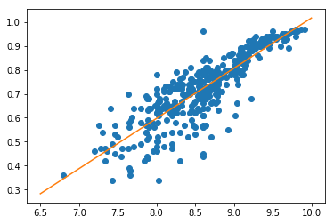

```python
m = theta1
b = theta0
x = np.linspace(6.5, 10, 10)
plt.plot(traindf['CGPA'], traindf['Chance of Admit'],'o')
plt.plot(x, m*x+b)
```

### Calculating NaN values of Chance of Admit variable

Firstly we seperate the NaN values from the data frame and calculate the value with the theta0 and theta1 obtained in the previous sections.

```python
testdf = tempdf[pd.isnull(newdf).any(axis=1)].copy()
testdf
```

|  | Serial No. | CGPA | Chance of Admit |
| --- | --- | --- | --- |
| 1 | 2 | 8.87 | NaN |
| 57 | 58 | 7.60 | NaN |
| 135 | 136 | 8.77 | NaN |
| 143 | 144 | 9.92 | NaN |
| 171 | 172 | 9.07 | NaN |
| 218 | 219 | 8.97 | NaN |
| 232 | 233 | 8.27 | NaN |
| 251 | 252 | 9.00 | NaN |
| 272 | 273 | 7.64 | NaN |
| 294 | 295 | 8.32 | NaN |
| 315 | 316 | 8.07 | NaN |
| 338 | 339 | 8.74 | NaN |
| 357 | 358 | 7.89 | NaN |
| 381 | 382 | 8.67 | NaN |
| 390 | 391 | 8.24 | NaN |
| 396 | 397 | 9.11 | NaN |

To calculate the Chance of Admit values we first drop the useless column of Chance of Admit calculate the values based on values of theta1 and theta0 and store them in a series and then add them to the Chance of Admit column once again.

```python
testdf.drop(columns = 'Chance of Admit')
```

|  | Serial No. | CGPA |
| --- | --- | --- |
| 1 | 2 | 8.87 |
| 57 | 58 | 7.60 |
| 135 | 136 | 8.77 |
| 143 | 144 | 9.92 |
| 171 | 172 | 9.07 |
| 218 | 219 | 8.97 |
| 232 | 233 | 8.27 |
| 251 | 252 | 9.00 |
| 272 | 273 | 7.64 |
| 294 | 295 | 8.32 |
| 315 | 316 | 8.07 |
| 338 | 339 | 8.74 |
| 357 | 358 | 7.89 |
| 381 | 382 | 8.67 |
| 390 | 391 | 8.24 |
| 396 | 397 | 9.11 |

```python
X_t = testdf['CGPA']
chanceOfAdmit = hypothesisFunc(theta0, theta1, X_t)
chanceOfAdmit
```

```
1      0.779704
57     0.513433
135    0.758737
143    0.999849
171    0.821636
218    0.800670
232    0.653906
251    0.806960
272    0.521819
294    0.664389
315    0.611974
338    0.752447
357    0.574235
381    0.737771
390    0.647616
396    0.830023
Name: CGPA, dtype: float64
```

```python
testdf['Chance of Admit'] = chanceOfAdmit
testdf
```

|  | Serial No. | CGPA | Chance of Admit |
| --- | --- | --- | --- |
| 1 | 2 | 8.87 | 0.779704 |
| 57 | 58 | 7.60 | 0.513433 |
| 135 | 136 | 8.77 | 0.758737 |
| 143 | 144 | 9.92 | 0.999849 |
| 171 | 172 | 9.07 | 0.821636 |
| 218 | 219 | 8.97 | 0.800670 |
| 232 | 233 | 8.27 | 0.653906 |
| 251 | 252 | 9.00 | 0.806960 |
| 272 | 273 | 7.64 | 0.521819 |
| 294 | 295 | 8.32 | 0.664389 |
| 315 | 316 | 8.07 | 0.611974 |
| 338 | 339 | 8.74 | 0.752447 |
| 357 | 358 | 7.89 | 0.574235 |
| 381 | 382 | 8.67 | 0.737771 |
| 390 | 391 | 8.24 | 0.647616 |
| 396 | 397 | 9.11 | 0.830023 |

Since in the assignment the serial number of students were asked to be shown in the final data frame, a temporary that contained serial numbers was saved.

## Conclusion

In this assignment we were introduced to a couple of functions in the pandas library and were able to use them to manipulate a dataframe in order to predict the probability of students getting admitted to universities for higher educations. Also we used the linear regression concepts to get the predictions.